# IODS course project

Fitting the model:

```r
model1 <- glm(high_use ~ sex + absences + activities + freetime, data = alc, family = "binomial")
summary(model1)
```

```
##
## Call:
## glm(formula = high_use ~ sex + absences + activities + freetime,
##     family = "binomial", data = alc)
##
## Deviance Residuals:
##     Min       1Q   Median       3Q      Max
## -2.1109  -0.8295  -0.6093   1.0538   2.0674
##
## Coefficients:
##               Estimate Std. Error z value Pr(>|z|)
## (Intercept)   -2.59915    0.46514  -5.588 2.30e-08 ***
## sexM           0.92543    0.24824   3.728 0.000193 ***
## absences       0.09799    0.02288   4.283 1.84e-05 ***
## activitiesyes -0.42169    0.24104  -1.749 0.080212 .
## freetime       0.30378    0.12540   2.423 0.015412 *
## ---
## Signif. codes:  0 '***' 0.001 '**' 0.01 '*' 0.05 '.' 0.1 ' ' 1
##
## (Dispersion parameter for binomial family taken to be 1)
##
##     Null deviance: 465.68  on 381  degrees of freedom
## Residual deviance: 421.40  on 377  degrees of freedom
## AIC: 431.4
##
## Number of Fisher Scoring iterations: 4
```

```r
#model coefficients
coef(model1)
```

```
##   (Intercept)          sexM      absences activitiesyes      freetime
##   -2.59915286    0.92543241    0.09798589   -0.42168759    0.30378445
```

```r
#compute odds ratios with confidence intervals
OR1 <- coef(model1) %>% exp
CI1 <- confint(model1) %>% exp
cbind(OR1, CI1)
```

```
##                      OR1      2.5 %    97.5 %
## (Intercept)   0.07433653 0.02903382 0.1804764
## sexM          2.52295897 1.55957211 4.1355002
## absences      1.10294723 1.05682865 1.1562064
## activitiesyes 0.65593893 0.40742321 1.0499293
## freetime      1.35497695 1.06271070 1.7394077
```

Statistical significance can be judged from the model coefficients, and a z-testi is used by default. Here we see that sex, number of absences and amount of free time have all positive and significant effect on high alcohol use. Having extra-curricular activities however has no statistically significant relation to high alcohol use in this data. The significance can also be judged from the confidence intervals of the odds ratio, where 1 is not included in the CI then the effect is significant. Hypotheses: 1. Being male increases the odds of being a high drinker between 1.56 and 4.14 times compared to females. Hypothesis is accepted. 2. Having a lot of absences increases the odds of being a high drinker by between 1.06 and 1.16 times for an incerease of 1 absence. 3. Having extra-curricular activities is less likely for high drinkers, but this effect is not significant in this data. 4. Having more free time increases the odds of being a high drinker between 1.06 and 1.74 times for an increase of 1 on a Likert scale of free time (from 1 = very low to 5 = very high).

Exploring model predictions:

```r
#create a model with all explanatory variables significant
model2 <- glm(high_use ~ sex + absences + freetime, data = alc, family = "binomial")
#predict
probabilities <- predict(model2, type = "response")
alc <- mutate(alc, probability = probabilities)
alc <- mutate(alc, prediction = probability > 0.5)

# 2 x 2 cross-tabulation
table(high_use = alc$high_use, prediction = alc$prediction)
```

```
##         prediction
## high_use FALSE TRUE
##    FALSE   254   14
##    TRUE     88   26
```

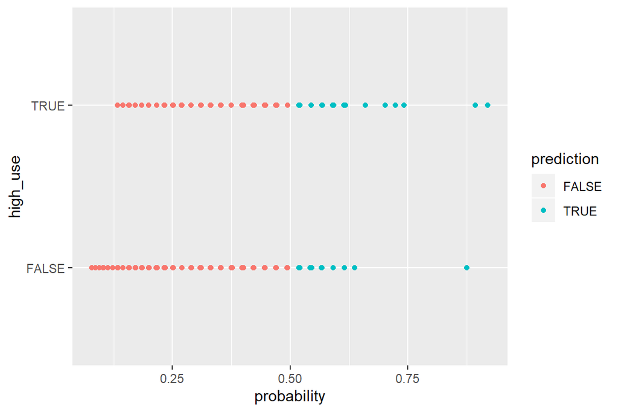

```r
#Graphical visualisation of predictions
library(ggplot2)
g <- ggplot(alc, aes(x = probability, y = high_use, col = prediction))
g + geom_point()
```

```r
#proportion of wrong predictions by using a loss function
loss_func <- function(class, prob) {
  n_wrong <- abs(class - prob) > 0.5
  mean(n_wrong)
}
loss_func(class = alc$high_use, prob = alc$probability)
```

```
## [1] 0.2670157
```

From the training error of about 27 % we can judge that the model is working much better compared to a simple 50/50 guess. 14 + 88 = 102 cases are predicted wrongly, most being correspondents of high alcohol use, but not caught by the model. This could indicate there are more factors affecting alcohol use, so maybe addition of new variables could increase model accuracy. In the graphic we can see a single “true” outlier, but clearly no cutoff is visible in the data where predictions are correct or incorrect.

```r
#10-fold cross-validation
library(boot)
cv <- cv.glm(data = alc, cost = loss_func, glmfit = model2, K = 10)
cv$delta[1]
```

```
## [1] 0.2774869
```

the predictative power of the 10-fold cross validation is similar but lower to the previous model as well as lower than the DataCamp example (error 0.26). The error rises in the cross validation, since less data is used to set up the model. Better models could be found if more predictors are included.

#week 4 clustering and classification

reading the data

```r
library(MASS)
data("Boston")
dim(Boston)
```

```
## [1] 506  14
```

```r
str(Boston)
```

```
## 'data.frame':    506 obs. of  14 variables:
##  $ crim   : num  0.00632 0.02731 0.02729 0.03237 0.06905 ...
##  $ zn     : num  18 0 0 0 0 0 12.5 12.5 12.5 12.5 ...
##  $ indus  : num  2.31 7.07 7.07 2.18 2.18 2.18 7.87 7.87 7.87 7.87 ...
##  $ chas   : int  0 0 0 0 0 0 0 0 0 0 ...
##  $ nox    : num  0.538 0.469 0.469 0.458 0.458 0.458 0.524 0.524 0.524 0.524 ...
##  $ rm     : num  6.58 6.42 7.18 7 7.15 ...
##  $ age    : num  65.2 78.9 61.1 45.8 54.2 58.7 66.6 96.1 100 85.9 ...
##  $ dis    : num  4.09 4.97 4.97 6.06 6.06 ...
##  $ rad    : int  1 2 2 3 3 3 5 5 5 5 ...
##  $ tax    : num  296 242 242 222 222 222 311 311 311 311 ...
##  $ ptratio: num  15.3 17.8 17.8 18.7 18.7 18.7 15.2 15.2 15.2 15.2 ...
##  $ black  : num  397 397 393 395 397 ...
##  $ lstat  : num  4.98 9.14 4.03 2.94 5.33 ...
##  $ medv   : num  24 21.6 34.7 33.4 36.2 28.7 22.9 27.1 16.5 18.9 ...
```

The Boston dataset is included in the R package MASS, and includes data on housing values in suburbs of Boston. What we are most interested here is the per capita crime rate in each of the suburbian towns, and how the towns can be classified according to this variable. The full description of the dataset can be accessed here: https://stat.ethz.ch/R-manual/R-devel/library/MASS/html/Boston.html.